# Estimating Subnational U5MR using Simulated Data

## Aggregation across strata

The `est.bb` object above computes the U5MR estimates by urban/rural strata. In order to obtain the overall region-specific U5MR, we need additional information on the population fractions of each stratum within regions. As an demonstration, we simulate the population totals over the years with

```r
pop.base <- expand.grid(region = c("central", "eastern", "northern", "western"),
    strata = c("urban", "rural"))
pop.base$population <- round(runif(dim(pop.base)[1], 1000, 20000))
periods.all <- c(periods, "15-19")
pop <- NULL
for (i in 1:length(periods.all)) {
    tmp <- pop.base
    tmp$population <- pop.base$population + round(rnorm(dim(pop.base)[1], mean = 0,
        sd = 200))
    tmp$years <- periods.all[i]
    pop <- rbind(pop, tmp)
}
head(pop)
```

```
##     region strata population years
## 1  central  urban      16641 85-89
## 2  eastern  urban       2662 85-89
## 3 northern  urban       4307 85-89
## 4  western  urban      13222 85-89
## 5  central  rural      16821 85-89
## 6  eastern  rural      17979 85-89
```

In order to compute the aggregated estimates, we need the proportion of urban/rural populations within each region in each time period.

```r
weight.strata <- expand.grid(region = c("central", "eastern", "northern", "western"),
    years = periods.all)
weight.strata$urban <- weight.strata$rural <- NA
for (i in 1:dim(weight.strata)[1]) {
    which.u <- which(pop$region == weight.strata$region[i] & pop$years == weight.strata$years[i] &
        pop$strata == "urban")
    which.r <- which(pop$region == weight.strata$region[i] & pop$years == weight.strata$years[i] &
        pop$strata == "rural")
    weight.strata[i, "urban"] <- pop$population[which.u]/(pop$population[which.u] +
        pop$population[which.r])
    weight.strata[i, "rural"] <- 1 - weight.strata[i, "urban"]
}
head(weight.strata)
```

```
##     region years rural urban
## 1  central 85-89  0.50  0.50
## 2  eastern 85-89  0.87  0.13
## 3 northern 85-89  0.37  0.63
## 4  western 85-89  0.36  0.64
## 5  central 90-94  0.51  0.49
## 6  eastern 90-94  0.87  0.13
```

Now we can recompute the smoothed estimates with the population fractions.

```r
est.bb <- getSmoothed(fit.bb, nsim = 1000, CI = 0.95, save.draws = TRUE, weight.strata = weight.strata)
head(est.bb$overall)
```

```
##    region years time area variance median mean upper lower rural urban
## 5 central 85-89    1    1  0.00112   0.23 0.23  0.30  0.17  0.50  0.50
## 6 central 90-94    2    1  0.00051   0.21 0.21  0.26  0.17  0.51  0.49
## 7 central 95-99    3    1  0.00034   0.19 0.19  0.23  0.16  0.50  0.50
## 1 central 00-04    4    1  0.00027   0.18 0.18  0.22  0.15  0.51  0.49
## 2 central 05-09    5    1  0.00025   0.17 0.17  0.20  0.14  0.50  0.50
## 3 central 10-14    6    1  0.00037   0.15 0.15  0.18  0.12  0.50  0.50
##   is.yearly years.num
## 5     FALSE        NA
## 6     FALSE        NA
## 7     FALSE        NA
## 1     FALSE        NA
## 2     FALSE        NA
## 3     FALSE        NA
```

We can compare the stratum-specific and aggregated U5MR estimates now.

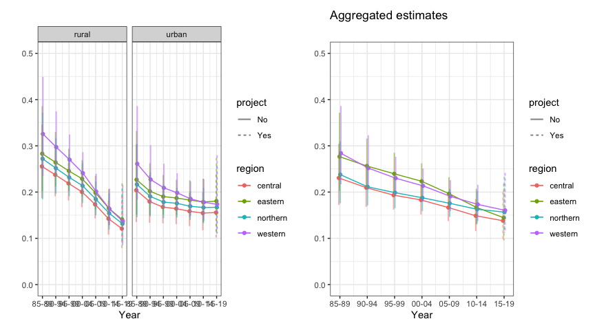

```r
g1 <- plot(est.bb$stratified, plot.CI = TRUE) + facet_wrap(~strata) + ylim(0, 0.5)
g2 <- plot(est.bb$overall, plot.CI = TRUE) + ylim(0, 0.5) + ggtitle("Aggregated estimates")
g1 + g2
```

# Visualizations

There are extensive visualization tools in the package. We can add hatching to the map visualizations to indicate uncertainty of the estimates using `hatchPlot` with similar syntax.

[figure not shown]

```r
hatchPlot(est.bb$overall,
        geo = DemoMap$geo, by.data = "region", by.geo = "REGNAME",
        is.long = TRUE, variables = "years", values = "median",
        lower = "lower", upper = "upper", hatch = "red",
        ncol = 4, direction = -1, per1000 = TRUE, legend.label = "U5MR")
```

Next we show the posterior densities of the estimates, where each each panel correspond to one time period, and the regions are ordered by the posterior median of estimates in the last year (specified by the `order = -1` argument).

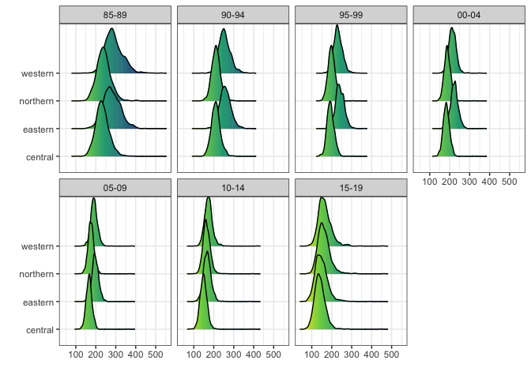

```r
ridgePlot(draws = est.bb, year.plot = periods.all,
                  ncol = 4, per1000 = TRUE, order = -1, direction = -1)
```

It can also be plotted for each region over time as well.

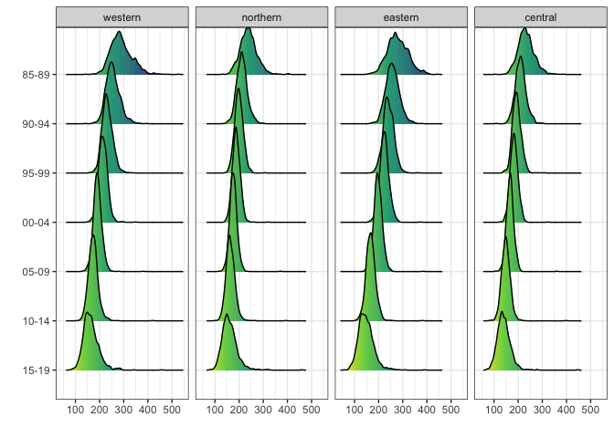

```r
ridgePlot(draws = est.bb, year.plot = periods.all,
                  ncol = 4, per1000 = TRUE, by.year = FALSE, direction = -1)
```

## Benchmarking to external information

When external estimates are available on the national level, we may want the subnational estimates to aggregate to the national estimates for internal validation purposes. Methods to benchmark to the national mean estimates were proposed in the literature. The vignette *A Case Study of Estimating Subnational U5MR using DHS data* demonstrates the approach described in Li et al. (2019) for the area-level model. The `bias.adj` argument in the `smoothCluster()` function allows one to adjust the estimates if the benchmarking ratio is known, using the approximation methods described in Wakefield et al. (2019). We refer readers to the package document for more details. Here we demonstrate a post-processing method described by Okonek and Wakefield (2022). It has the additional advantage that both the mean and uncertainty of the national estimates are accounted for in the benchmarking process.

To demonstrate the function, we first simulate national estimates. For a realistic simulation, we reuse the national direct estimates and add a constant bias term. We assume these estimates are from an external source. Thus we expect the estimates after benchmarking will be larger in general.

```r
national <- data.frame(years = periods.all, est = out1$median + 0.01, sd = runif(7,
    0.01, 0.03))
head(national)
```

```
##   years  est    sd
## 1 85-89 0.24 0.020
## 2 90-94 0.23 0.012
## 3 95-99 0.21 0.025
## 4 00-04 0.22 0.023
## 5 05-09 0.20 0.018
## 6 10-14 0.17 0.025
```

In order to perform the benchmarking process, we need the proportion of population by region over the time periods. We can compute these from the simulated population before.

```r
weight.region <- expand.grid(region = c("central", "eastern", "northern", "western"),
    years = periods.all)
weight.region$proportion <- NA
for (i in 1:dim(weight.region)[1]) {
    which <- which(pop$region == weight.strata$region[i] & pop$years == weight.strata$years[i])
    which.year <- which(pop$years == weight.strata$years[i])
    weight.region[i, "proportion"] <- sum(pop$population[which])/sum(pop$population[which.year])
}
head(weight.region)
```

```
##     region years proportion
## 1  central 85-89      0.410
## 2  eastern 85-89      0.253
## 3 northern 85-89      0.084
## 4  western 85-89      0.253
## 5  central 90-94      0.413
## 6  eastern 90-94      0.256
```

We perform the benchmarking procedure using the `Benchmark` function

```r
est.bb.bench <- Benchmark(est.bb, national, weight.region = weight.region, estVar = "est",
    sdVar = "sd", timeVar = "years")
```

Since the benchmarking procedure is based on a rejection sampler, the number of posterior draws accepted after benchmarking can be small, as in this example. We recommend increasing the number of draws first, i.e.,

```r
est.bb <- getSmoothed(fit.bb, nsim = 20000, CI = 0.95, save.draws = TRUE, weight.strata = weight.strata)
est.bb.bench <- Benchmark(est.bb, national, weight.region = weight.region, estVar = "est",
    sdVar = "sd", timeVar = "years")
```

We can compare the posterior median and variance before and after benchmarking.

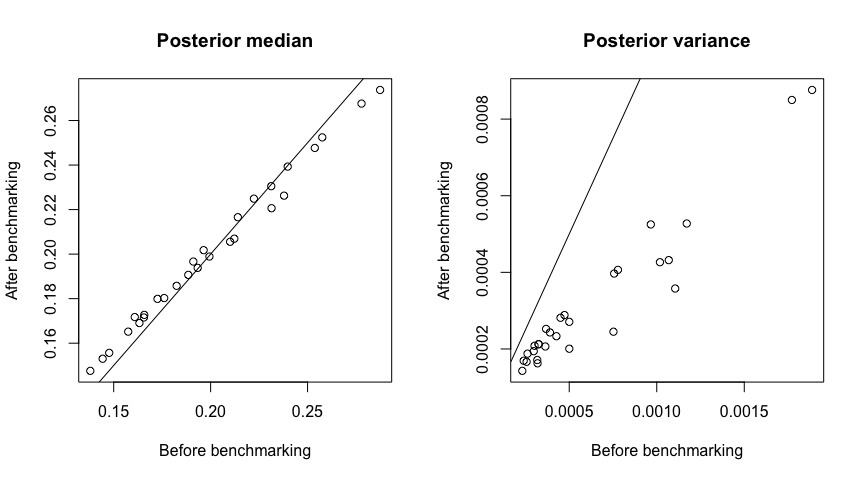

```r
par(mfrow = c(1, 2))
plot(est.bb$overall$median, est.bb.bench$overall$median, xlab = "Before benchmarking",
    ylab = "After benchmarking", main = "Posterior median")
abline(c(0, 1))
plot(est.bb$overall$variance, est.bb.bench$overall$variance, xlab = "Before benchmarking",
    ylab = "After benchmarking", main = "Posterior variance")
abline(c(0, 1))
```

As an sanity check, we can compute the simple weighted average of the posterior median of all regions to form a set of rough national estimates. It can be seen that the benchmarked estimates are indeed higher and closer to the simulated national estimates benchmarked against.

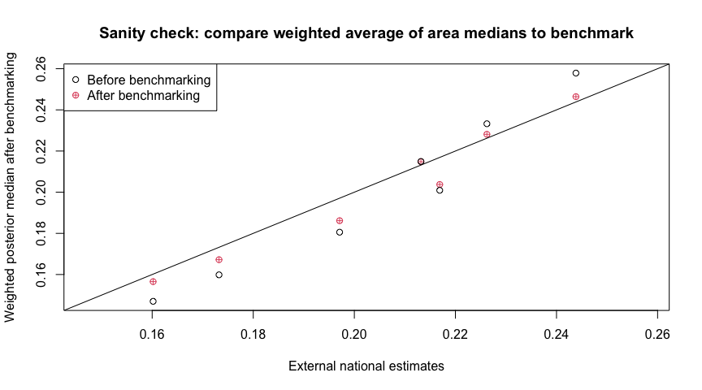

```r
compare <- national
compare$before <- NA
compare$after <- NA
for (i in 1:dim(compare)[1]) {
    weights <- subset(weight.region, years == national$years[i])
    sub <- subset(est.bb$overall, years == national$years[i])
    sub <- merge(sub, weights)
    sub.bench <- subset(est.bb.bench$overall, years == national$years[i])
    sub.bench <- merge(sub.bench, weights)
    compare$before[i] <- sum(sub$proportion * sub$median)
    compare$after[i] <- sum(sub.bench$proportion * sub.bench$median)
}
plot(compare$est, compare$after, col = 2, pch = 10, xlim = range(c(compare$est, compare$before,
    compare$after)), ylim = range(c(compare$est, compare$before, compare$after)),
    xlab = "External national estimates", ylab = "Weighted posterior median after benchmarking",
    main = "Sanity check: compare weighted average of area medians to benchmark")
points(compare$est, compare$before)
abline(c(0, 1))
legend("topleft", c("Before benchmarking", "After benchmarking"), pch = c(1, 10),
    col = c(1, 2))
```

### References

Fuglstad, Geir-Arne, Zehang Richard Li, and Jon Wakefield. 2021. “The Two Cultures for Prevalence Mapping: Small Area Estimation and Spatial Statistics.” *arXiv Preprint arXiv:2110.09576*.

Li, Zehang R, Yuan Hsiao, Jessica Godwin, Bryan D Martin, Jon Wakefield, and Samuel J Clark. 2019. “Changes in the Spatial Distribution of the Under Five Mortality Rate: Small-Area Analysis of 122 DHS Surveys in 262 Subregions of 35 Countries in Africa.” *PLoS One*.

Martin, Bryan D, Dong Tracy Qi, Geir-Arne Fuglstad, Jessica Godwin, John Paige, Andrea Riebler, Samuel J Clark, and Jon Wakefield. 2020. “[Space-Time Smoothing of Demographic and Health Indicators Using the R Package SUMMER](https://arxiv.org/abs/2007.05117).” *Submitted*.

Okonek, Taylor, and Jon Wakefield. 2022. “A Computationally Efficient Approach to Fully Bayesian Benchmarking.” *arXiv Preprint arXiv:2203.12195*.

Wakefield, J., G.-A. Fuglstad, A. Riebler, J. Godwin, K. Wilson, and S. J. Clark. 2019. “Estimating Under Five Mortality in Space and Time in a Developing World Context.” *Statistical Methods in Medical Research* 28: 2614–34.